Daniel van Strien

# A (very brief) intro to exploring metadata on the Hugging Face Hub

How we can use the `huggingface_hub` library to explore metadata on the Hugging Face Hub.

Jan 15, 2023 • 25 min read

huggingface metadata

- Library imports
- Tags
  - Grouping by pipeline tags
- Why counting tags might not make sense

The Hugging Face Hub has become the de facto place to share machine learning models and datasets. As the number of models and datasets grow the challenge of finding the right model or dataset for your needs may become more challenging. There are various ways in which we can try and make it easier for people to find relevant models and datasets. One of these is by associating metadata with datasets and models. This blog post will (very briefly) begin to explore metadata on the Hugging Face Hub. Often you'll want to explore models and datasets via the Hub website but this isn't the only way to explore the Hub. As part of the process of exploring metadata on the Hugging Face Hub we'll briefly look at how we can use the `huggingface_hub` library to programmatically interact with the Hub.

## Library imports

For this post we'll need a few libraries, `pandas`, `requests` and `matplotlib` are likely old friends (or foes...). The `huggingface_hub` library might be new to you but will soon become a good friend too! The `rich` library is fantastically useful for quickly getting familiar with a library (i.e. avoiding reading all the docs!) so we'll import that too.

```python
import requests
from huggingface_hub import hf_api
import pandas as pd
import matplotlib.pyplot as plt
import rich
```

```python
%matplotlib inline
plt.style.use("ggplot")
```

We'll instantiate an instance of the `HfApi` class.

```python
api = hf_api.HfApi()
```

We can use `rich` `inspect` to get a better sense of what a function or class instance is all about. Let's see what methods the api has.

```python
rich.inspect(api, methods=True)
```

```
╭──────────────────────────────────── <class 'huggingface_hub.hf_api.HfApi'> ─────────────────────────────────────╮
│ ╭─────────────────────────────────────────────────────────────────────────────────────────────────────────────╮ │
│ │ <huggingface_hub.hf_api.HfApi object at 0x136a2ce80>                                                        │ │
│ ╰─────────────────────────────────────────────────────────────────────────────────────────────────────────────╯ │
│                                                                                                                 │
│                 endpoint = 'https://huggingface.co'                                                             │
│                    token = None                                                                                 │
│ change_discussion_status = def change_discussion_status(repo_id: str, discussion_num: int, new_status:          │
│                            Literal['open', 'closed'], *, token: Optional[str] = None, comment: Optional[str] =  │
│                            None, repo_type: Optional[str] = None) ->                                            │
│                            huggingface_hub.community.DiscussionStatusChange: Closes or re-opens a Discussion or │
│                            Pull Request.                                                                        │
│       comment_discussion = def comment_discussion(repo_id: str, discussion_num: int, comment: str, *, token:    │
│                            Optional[str] = None, repo_type: Optional[str] = None) ->                            │
│                            huggingface_hub.community.DiscussionComment: Creates a new comment on the given      │
│                            Discussion.                                                                          │
│            create_branch = def create_branch(repo_id: str, *, branch: str, token: Optional[str] = None,         │
│                            repo_type: Optional[str] = None) -> None: Create a new branch from `main` on a repo  │
│                            on the Hub.                                                                          │
│            create_commit = def create_commit(repo_id: str, operations:                                          │
│                            Iterable[Union[huggingface_hub._commit_api.CommitOperationAdd,                       │
│                            huggingface_hub._commit_api.CommitOperationDelete]], *, commit_message: str,         │
│                            commit_description: Optional[str] = None, token: Optional[str] = None, repo_type:    │
│                            Optional[str] = None, revision: Optional[str] = None, create_pr: Optional[bool] =    │
│                            None, num_threads: int = 5, parent_commit: Optional[str] = None) ->                  │
│                            huggingface_hub.hf_api.CommitInfo: Creates a commit in the given repo, deleting &    │
│                            uploading files as needed.                                                           │
│        create_discussion = def create_discussion(repo_id: str, title: str, *, token: Optional[str] = None,      │
│                            description: Optional[str] = None, repo_type: Optional[str] = None, pull_request:    │
│                            bool = False) -> huggingface_hub.community.DiscussionWithDetails: Creates a          │
│                            Discussion or Pull Request.                                                          │
│      create_pull_request = def create_pull_request(repo_id: str, title: str, *, token: Optional[str] = None,    │
│                            description: Optional[str] = None, repo_type: Optional[str] = None) ->               │
│                            huggingface_hub.community.DiscussionWithDetails: Creates a Pull Request . Pull       │
│                            Requests created programmatically will be in `"draft"` status.                       │
│              create_repo = def create_repo(repo_id: str, *, token: Optional[str] = None, private: bool = False, │
│                            repo_type: Optional[str] = None, exist_ok: bool = False, space_sdk: Optional[str] =  │
│                            None) -> str: Create an empty repo on the HuggingFace Hub.                           │
│               create_tag = def create_tag(repo_id: str, *, tag: str, tag_message: Optional[str] = None,         │
│                            revision: Optional[str] = None, token: Optional[str] = None, repo_type:              │
```

[output cut: 108 more lines]

```
│                            parent_commit: Optional[str] = None) -> str:                                         │
│                            Upload a local file (up to 50 GB) to the given repo. The upload is done              │
│                            through a HTTP post request, and doesn't require git or git-lfs to be                │
│                            installed.                                                                           │
│            upload_folder = def upload_folder(*, repo_id: str, folder_path: Union[str, pathlib.Path],            │
│                            path_in_repo: Optional[str] = None, commit_message: Optional[str] = None,            │
│                            commit_description: Optional[str] = None, token: Optional[str] = None, repo_type:    │
│                            Optional[str] = None, revision: Optional[str] = None, create_pr: Optional[bool] =    │
│                            None, parent_commit: Optional[str] = None, allow_patterns: Union[List[str], str,     │
│                            NoneType] = None, ignore_patterns: Union[List[str], str, NoneType] = None):          │
│                            Upload a local folder to the given repo. The upload is done                          │
│                            through a HTTP requests, and doesn't require git or git-lfs to be                    │
│                            installed.                                                                           │
│                   whoami = def whoami(token: Optional[str] = None) -> Dict: Call HF API to know "whoami".       │
╰─────────────────────────────────────────────────────────────────────────────────────────────────────────────────╯
```

You'll see from looking through this there is a bunch of different things we can now do programmatically via the hub. For this post we're interested in the `list_datasets` and `list_models` methods. If we look at one of these we can see it has a bunch of different options we can use when listing datasets or models.

```python
rich.inspect(api.list_models)
```

```
╭─────────── <bound method HfApi.list_models of <huggingface_hub.hf_api.HfApi object at 0x136a2ce80>> ────────────╮
│ def HfApi.list_models(*, filter: Union[huggingface_hub.utils.endpoint_helpers.ModelFilter, str, Iterable[str],  │
│ NoneType] = None, author: Optional[str] = None, search: Optional[str] = None, emissions_thresholds:             │
│ Optional[Tuple[float, float]] = None, sort: Union[Literal['lastModified'], str, NoneType] = None, direction:    │
│ Optional[Literal[-1]] = None, limit: Optional[int] = None, full: Optional[bool] = None, cardData: bool = False, │
│ fetch_config: bool = False, token: Union[bool, str, NoneType] = None) ->                                        │
│ List[huggingface_hub.hf_api.ModelInfo]:                                                                         │
│                                                                                                                 │
│ Get the list of all the models on huggingface.co                                                                │
│                                                                                                                 │
│ 28 attribute(s) not shown. Run inspect(inspect) for options.                                                    │
╰─────────────────────────────────────────────────────────────────────────────────────────────────────────────────╯
```

For our use case we want everything, so we set `limit=None`, we don't want any `filters` so we set this to `None` (this is the default behaviour, but we set them explicitly here to make it clearer for our future selves). We also set `full=True` so we get back more verbose information about our dataset and models. We also wrap the result in `iter` and `list` since the behaviour of these methods will change in future versions to support paging.

```python
hub_datasets = list(iter(api.list_datasets(limit=None, filter=None, full=True)))
```

```python
hub_models = list(iter(api.list_models(limit=None, filter=None, full=True)))
```

Let's peek at an example of what we get back

```python
hub_models[0]
```

```
ModelInfo: {
	modelId: albert-base-v1
	sha: aeffd769076a5c4f83b2546aea99ca45a15a5da4
	lastModified: 2021-01-13T15:08:24.000Z
	tags: ['pytorch', 'tf', 'albert', 'fill-mask', 'en', 'dataset:bookcorpus', 'dataset:wikipedia', 'arxiv:1909.11942', 'transformers', 'exbert', 'license:apache-2.0', 'autotrain_compatible', 'has_space']
	pipeline_tag: fill-mask
	siblings: [RepoFile(rfilename='.gitattributes', size='None', blob_id='None', lfs='None'), RepoFile(rfilename='README.md', size='None', blob_id='None', lfs='None'), RepoFile(rfilename='config.json', size='None', blob_id='None', lfs='None'), RepoFile(rfilename='pytorch_model.bin', size='None', blob_i…
	private: False
	author: None
	config: None
	securityStatus: None
	_id: 621ffdc036468d709f174328
	id: albert-base-v1
	gitalyUid: 4f35551ea371da7a8762caab54319a54ade836044f0ca7690d21e86b159867eb
	likes: 1
	downloads: 75182
	library_name: transformers
}
```

```python
hub_datasets[0]
```

```
DatasetInfo: {
	id: acronym_identification
	sha: 173af1516c409eb4596bc63a69626bdb5584c40c
	lastModified: 2022-11-18T17:25:49.000Z
	tags: ['task_categories:token-classification', 'annotations_creators:expert-generated', 'language_creators:found', 'multilinguality:monolingual', 'size_categories:10K<n<100K', 'source_datasets:original', 'language:en', 'license:mit', 'acronym-identification', 'arxiv:2010.14678']
	private: False
	author: None
	description: Acronym identification training and development sets for the acronym identification task at SDU@AAAI-21.
	citation: @inproceedings{veyseh-et-al-2020-what,
   title={{What Does This Acronym Mean? Introducing a New Dataset for Acronym Identification and Disambiguation}},
   author={Amir Pouran Ben Veyseh and Franck Dernoncourt and Quan Hung Tran and Thien Huu Nguyen},
   year={2020},
   booktitle={Proceedings of COLING},
   link={https://arxiv.org/pdf/2010.14678v1.pdf}
}
	cardData: {'annotations_creators': ['expert-generated'], 'language_creators': ['found'], 'language': ['en'], 'license': ['mit'], 'multilinguality': ['monolingual'], 'size_categories': ['10K<n<100K'], 'source_datasets': ['original'], 'task_categories': ['token-classification'], 'task_ids': [], 'pape…
	siblings: []
	_id: 621ffdd236468d709f181d58
	disabled: False
	gated: False
	gitalyUid: 6570517623fa521aa189178e7c7e73d9d88c01b295204edef97f389a15eae144
	likes: 9
	downloads: 6074
	paperswithcode_id: acronym-identification
}
```

Since we want both models and datasets we create a dictionary which stores the types of item i.e. is it a dataset or a model.

```python
hub_data = {"model": hub_models, "dataset": hub_datasets}
```

We'll be putting our data inside a pandas DataFrame, so we'll grab the `.__dict__` attribute for each hub item, so it's more pandas friendly.

```python
hub_item_dict = []
for hub_type, hub_item in hub_data.items():
    for item in hub_item:
        data = item.__dict__
        data["type"] = hub_type
        hub_item_dict.append(data)
```

```python
df = pd.DataFrame.from_dict(hub_item_dict)
```

How many hub items do we have?

```python
len(df)
```

```
151343
```

What info do we have?

```python
df.columns
```

```
Index(['modelId', 'sha', 'lastModified', 'tags', 'pipeline_tag', 'siblings',
       'private', 'author', 'config', 'securityStatus', '_id', 'id',
       'gitalyUid', 'likes', 'downloads', 'library_name', 'type',
       'description', 'citation', 'cardData', 'disabled', 'gated',
       'paperswithcode_id'],
      dtype='object')
```

## Tags

Models and datasets have a bunch of metadata i.e. last modified and number of downloads. We'll focus on `tags` here. Let's start by looking at a single example.

```python
df.loc[30, "tags"]
```

```
['pytorch',
 'tf',
 'rust',
 'safetensors',
 'distilbert',
 'text-classification',
 'en',
 'dataset:sst2',
 'dataset:glue',
 'doi:10.57967/hf/0181',
 'transformers',
 'license:apache-2.0',
 'model-index',
 'has_space']
```

We can see that `tags` capture can relate to tasks i.e. `text-classification`, libraries supported i.e. `tf`, or the `licence` associated with a model or dataset. As a starting point for exploring tags we can take a look at how many tags models and datasets have. We'll add a new column to capture this number.

```python
def calculate_number_of_tags(tags: [str]) -> int:
    return len(tags)
```

```python
df["number_of_tags"] = df["tags"].apply(lambda x: calculate_number_of_tags(x))
```

We can now use `describe` to see the breakdown of this number.

```python
df.number_of_tags.describe()
```

```
count    151343.000000
mean          3.855566
std           6.878613
min           0.000000
25%           0.000000
50%           4.000000
75%           6.000000
max         650.000000
Name: number_of_tags, dtype: float64
```

We can see that we have quite a range of tag numbers ranging from `0` to `650`! If your brain works anything like mine you probably want to know what this high value is about!

```python
df[df.number_of_tags > 640][["id", "tags"]]
```

|  | id | tags |
| --- | --- | --- |
| 136372 | bible-nlp/biblenlp-corpus | [task_categories:translation, annotations_crea... |

```python
df[df.number_of_tags > 640]["tags"].tolist()
```

```
[['task_categories:translation',
  'annotations_creators:no-annotation',
  'language_creators:expert-generated',
  'multilinguality:translation',
  'multilinguality:multilingual',
  'size_categories:1M<n<10M',
  'source_datasets:original',
  'language:aau',
  'language:aaz',
  'language:abx',
  'language:aby',
  'language:acf',
  'language:acu',
  'language:adz',
  'language:aey',
  'language:agd',
  'language:agg',
  'language:agm',
  'language:agn',
  'language:agr',
  'language:agu',
  'language:aia',
  'language:ake',
  'language:alp',
  'language:alq',
  'language:als',
  'language:aly',
  'language:ame',
  'language:amk',
  'language:amp',
  'language:amr',
  'language:amu',
  'language:anh',
  'language:anv',
  'language:aoi',
  'language:aoj',
  'language:apb',
  'language:apn',
  'language:apu',
  'language:apy',
```

[output cut: 595 more lines]

```
  'language:it',
  'language:ja',
  'language:la',
  'language:nl',
  'language:ru',
  'language:sa',
  'language:so',
  'language:es',
  'language:sr',
  'language:sv',
  'language:to',
  'language:uk',
  'language:vi',
  'license:cc-by-4.0',
  'license:other']]
```

We can see that in this case many of the tags relate to language. Since the dataset is bible related and the bible has been heavily translated this might not be as surprising.

Although these high-level stats are somewhat interesting we probably want to break these numbers down. At a high level we can groupby datasets vs models.

```python
df.groupby("type")["number_of_tags"].describe()
```

| type | count | mean | std | min | 25% | 50% | 75% | max |
| --- | --- | --- | --- | --- | --- | --- | --- | --- |
| dataset | 19576.0 | 2.46935 | 13.137220 | 0.0 | 0.0 | 0.0 | 2.0 | 650.0 |
| model | 131767.0 | 4.06151 | 5.327066 | 0.0 | 0.0 | 4.0 | 6.0 | 413.0 |

We can see that the mean number of tags for models is higher than datasets. We can also see at the 75% percentile models also have more tags compared to datasets. The possible reasons for this (and whether this is a problem or not) is something we may wish to explore further...

Since the hub hosts models from different libraries we may want to also breakdown by library. First let's grab only the model part of our DataFrame.

```python
models_df = df[df["type"] == "model"]
```

The `library_name` column contains info about the library. Let's see how many unique libraries we have.

```python
models_df.library_name.unique().shape
```

```
(63,)
```

This is quite a few! We can do a groupby on this column

```python
models_df.groupby("library_name")["number_of_tags"].describe()
```

| library_name | count | mean | std | min | 25% | 50% | 75% | max |
| --- | --- | --- | --- | --- | --- | --- | --- | --- |
| BERT | 1.0 | 7.0 | NaN | 7.0 | 7.0 | 7.0 | 7.0 | 7.0 |
| Doc-UFCN | 2.0 | 4.0 | 0.000000 | 4.0 | 4.0 | 4.0 | 4.0 | 4.0 |
| EveryDream | 2.0 | 7.0 | 0.000000 | 7.0 | 7.0 | 7.0 | 7.0 | 7.0 |
| FastAI | 1.0 | 1.0 | NaN | 1.0 | 1.0 | 1.0 | 1.0 | 1.0 |
| JoeyNMT | 1.0 | 4.0 | NaN | 4.0 | 4.0 | 4.0 | 4.0 | 4.0 |
| ... | ... | ... | ... | ... | ... | ... | ... | ... |
| ultralytics | 4.0 | 10.0 | 1.414214 | 8.0 | 9.5 | 10.5 | 11.0 | 11.0 |
| ultralyticsplus | 1.0 | 9.0 | NaN | 9.0 | 9.0 | 9.0 | 9.0 | 9.0 |
| yolor | 2.0 | 9.0 | 0.000000 | 9.0 | 9.0 | 9.0 | 9.0 | 9.0 |
| yolov5 | 36.0 | 9.0 | 0.000000 | 9.0 | 9.0 | 9.0 | 9.0 | 9.0 |
| yolov6detect | 1.0 | 10.0 | NaN | 10.0 | 10.0 | 10.0 | 10.0 | 10.0 |

62 rows × 8 columns

We might find this a bit tricky to look at. We may want to only include the top n libraries since some of these libraries may be less well used.

```python
models_df.library_name.value_counts()[:15]
```

```
transformers             63754
stable-baselines3         3183
diffusers                 2802
sentence-transformers     1273
ml-agents                  763
keras                      470
timm                       383
espnet                     381
spacy                      296
sample-factory             273
adapter-transformers       201
sklearn                    113
nemo                       103
fastai                      99
speechbrain                 94
Name: library_name, dtype: int64
```

```python
top_libraries = models_df.library_name.value_counts()[:9].index.to_list()
```

```python
top_libraries_df = models_df[models_df.library_name.isin(top_libraries)]
```

```python
top_libraries_df.groupby("library_name")["number_of_tags"].describe()
```

| library_name | count | mean | std | min | 25% | 50% | 75% | max |
| --- | --- | --- | --- | --- | --- | --- | --- | --- |
| diffusers | 2802.0 | 4.374732 | 2.171226 | 1.0 | 3.0 | 4.0 | 5.0 | 18.0 |
| espnet | 381.0 | 6.965879 | 0.595060 | 3.0 | 7.0 | 7.0 | 7.0 | 9.0 |
| keras | 470.0 | 3.842553 | 14.422674 | 1.0 | 1.0 | 2.0 | 5.0 | 311.0 |
| ml-agents | 763.0 | 6.965924 | 0.273775 | 2.0 | 7.0 | 7.0 | 7.0 | 7.0 |
| sentence-transformers | 1273.0 | 6.984289 | 3.221840 | 2.0 | 6.0 | 6.0 | 7.0 | 36.0 |
| spacy | 296.0 | 4.611486 | 0.985180 | 2.0 | 4.0 | 5.0 | 5.0 | 10.0 |
| stable-baselines3 | 3183.0 | 4.997801 | 0.163426 | 3.0 | 5.0 | 5.0 | 5.0 | 8.0 |
| timm | 383.0 | 3.548303 | 1.315291 | 2.0 | 3.0 | 3.0 | 3.0 | 13.0 |
| transformers | 63754.0 | 6.912037 | 5.262633 | 1.0 | 5.0 | 6.0 | 8.0 | 240.0 |

Let's take a quick look at some examples from the library with the highest and lowest number or tags.

```python
top_libraries_df[top_libraries_df.library_name == "sentence-transformers"].sample(15)[
    "tags"
]
```

```
6123      [pytorch, gpt_neo, arxiv:2202.08904, sentence-...
2488      [pytorch, distilbert, sentence-transformers, f...
37669     [pytorch, distilbert, sentence-transformers, f...
71483     [pytorch, bert, sentence-transformers, feature...
20710     [pytorch, tf, roberta, ko, sentence-transforme...
27073     [pytorch, tf, jax, roberta, arxiv:1908.10084, ...
92037     [pytorch, mpnet, sentence-transformers, featur...
90320     [pytorch, mpnet, sentence-transformers, featur...
63555     [pytorch, bert, sentence-transformers, feature...
87707     [pytorch, mpnet, sentence-transformers, featur...
80570     [pytorch, bert, sentence-transformers, feature...
111407    [pytorch, bert, sentence-transformers, feature...
82690     [pytorch, mpnet, sentence-transformers, featur...
36217     [pytorch, bert, pl, dataset:Wikipedia, arxiv:1...
100086    [pytorch, roberta, sentence-transformers, feat...
Name: tags, dtype: object
```

```python
top_libraries_df[top_libraries_df.library_name == "timm"].sample(15)["tags"]
```

```
104432                [pytorch, timm, image-classification]
110296    [pytorch, arxiv:2301.00808, timm, image-classi...
24158                 [pytorch, timm, image-classification]
26471                 [pytorch, timm, image-classification]
104437                [pytorch, timm, image-classification]
61630     [pytorch, dataset:beans, timm, image-classific...
110298    [pytorch, arxiv:2301.00808, timm, image-classi...
104015                [pytorch, timm, image-classification]
101124                [pytorch, timm, image-classification]
57882     [coreml, onnx, en, dataset:imagenet-1k, arxiv:...
83459     [pytorch, timm, image-classification, vision, ...
99461                 [pytorch, timm, image-classification]
104029                [pytorch, timm, image-classification]
84402     [pytorch, timm, image-classification, vision, ...
104428                [pytorch, timm, image-classification]
Name: tags, dtype: object
```

We can see here that some tags for `sentence-transformers` are very closely tied to that libraries purpose e.g. the `sentence-similarity` tag. This tag migth be useful when a user is looking for models to do `sentence-similarity` but might be less useful if you are trying to choose *between* models for this task i.e. trying to find the `setence-transformer` model that will be useful for you. We should be careful, therefore, in treating number of tags as a proxy for quality.

### Grouping by pipeline tags

We have a column in our dataframe `pipeline` tag, which refers to the type of task a model is for. We should be careful relying too much on this but we can have a quick look at how often these are used.

```python
models_df["pipeline_tag"].value_counts()
```

```
text-classification               14479
text2text-generation               8102
text-generation                    7602
reinforcement-learning             6885
token-classification               6386
automatic-speech-recognition       6238
fill-mask                          5447
question-answering                 3147
feature-extraction                 2661
translation                        1837
conversational                     1770
image-classification               1760
text-to-image                      1604
sentence-similarity                1248
summarization                       735
unconditional-image-generation      428
text-to-speech                      244
audio-classification                234
multiple-choice                     169
object-detection                    158
image-segmentation                  134
audio-to-audio                      130
tabular-classification               97
zero-shot-classification             97
image-to-text                        76
zero-shot-image-classification       56
video-classification                 50
table-question-answering             47
tabular-regression                   44
image-to-image                       43
depth-estimation                     37
document-question-answering          18
visual-question-answering            13
voice-activity-detection              6
other                                 4
time-series-forecasting               1
Name: pipeline_tag, dtype: int64
```

We may also want to see if there are some type of task that have more tags.

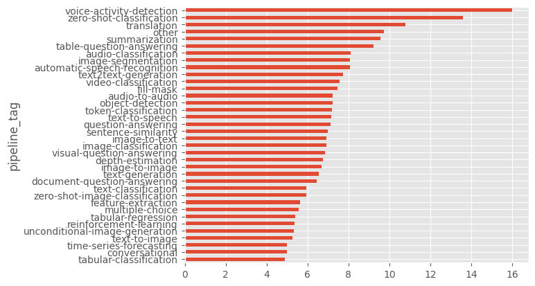

```python
models_df.groupby("pipeline_tag")["number_of_tags"].mean().sort_values().plot.barh()
```

We can also look at the breakdown for a particular task

```python
text_classification_df = models_df[models_df["pipeline_tag"] == "text-classification"]
```

```python
text_classification_df["number_of_tags"].describe()
```

```
count    14479.000000
mean         5.948822
std          3.718800
min          1.000000
25%          4.000000
50%          5.000000
75%          7.000000
max        240.000000
Name: number_of_tags, dtype: float64
```

Again, we have some extreme outliers

```python
text_classification_df[text_classification_df.number_of_tags > 230][["tags", "modelId"]]
```

|  | tags | modelId |
| --- | --- | --- |
| 22457 | [pytorch, tf, roberta, text-classification, mu... | m3hrdadfi/zabanshenas-roberta-base-mix |
| 101628 | [pytorch, canine, text-classification, ace, af... | SebOchs/canine-c-lang-id |

We see that these mostly seem to relate to language. Let's remove these outliers and look at the distribution in the number of tags without these.

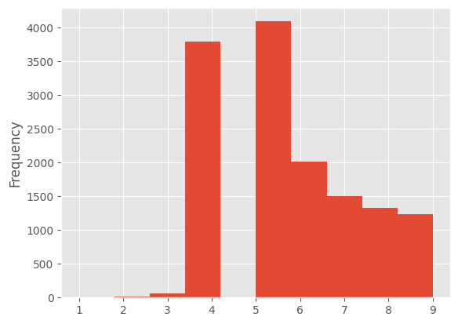

```python
text_classification_df_no_outliers = text_classification_df[
    text_classification_df["number_of_tags"]
    <= text_classification_df["number_of_tags"].quantile(0.95)
]
text_classification_df_no_outliers["number_of_tags"].plot.hist(bins=10)
```

## Why counting tags might not make sense

I'e already hinted at why looking at raw number of tags might not be a good idea. Let's close this blog by briefly digging into at least one reason why. We'll use the toolz library for some of this analysis.

```python
from toolz import concat
```

First we grab all the tags and put them in a single list.

```python
all_tags = list(concat(df.tags.tolist()))
```

If we look at some examples, we'll see some tags are in the form of `something:somethingelse`.

```python
all_tags[:10]
```

```
['pytorch',
 'tf',
 'albert',
 'fill-mask',
 'en',
 'dataset:bookcorpus',
 'dataset:wikipedia',
 'arxiv:1909.11942',
 'transformers',
 'exbert']
```

for example `dataset:wikipedia`, we should therefore avoid treating all tags as the same since tags can have a particular purpose. i.e. indicating a dataset is associated with a model.

```python
def is_special_tag(tag: str):
    return ":" in tag
```

```python
from toolz import countby, valmap
```

```python
special_tag_vs_normal = countby(is_special_tag, all_tags)
```

```python
special_tag_vs_normal
```

```
{False: 467758, True: 115755}
```

```python
total = sum(special_tag_vs_normal.values())
valmap(lambda x: x / total, special_tag_vs_normal)
```

```
{False: 0.8016239569641121, True: 0.1983760430358878}
```

We can see that a good chunk of tags are 'special' tags. i.e. they have a 'type' associated with them. If we want to explore tags on the hub more carefully we'll need to take this into account...